# Tarea 1 — Series de tiempo

### 6.2.1 Gráfico Final

**Mostrar/ocultar código**

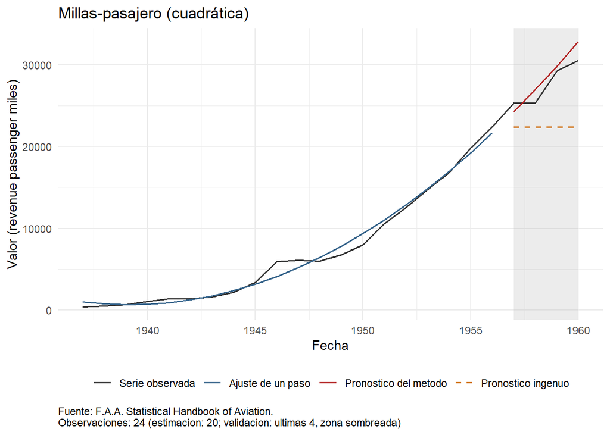

```r
g_final <- grafico_pronostico(datos, n_est, ajuste$yhat, pron, "Millas-pasajero (cuadrática)", ingenuo = pron_ing)
ggsave("figs/e6-final.png", g_final, width = 8, height = 4.5)
g_final
```

En la gráfica se evidencia que el modelo de Tendencia Cuadrática logra captar muy bien el comportamiento de la serie, adaptándose de forma adecuada al crecimiento acelerado que presenta a lo largo del tiempo. A diferencia del modelo ingenuo, que proyecta una línea plana al ignorar la dinámica de los datos, la tendencia cuadrática acompaña de cerca la trayectoria real en el periodo de evaluación.

Sin embargo, al examinar la zona de pronóstico (área sombreada), se observa que la línea roja del modelo queda ligeramente por encima de la línea negra observada. Esto sucede porque la curva del modelo proyecta un impulso hacia arriba un poco más pronunciado que la desaceleración suave que experimentó la serie en los últimos periodos.

**Conclusión:** Se ajustó un modelo de Tendencia Cuadrática con coeficientes $\hat{\beta}_1 = 473.93$ y $\hat{\beta}_2 = 74.33$, utilizando 20 observaciones de entrenamiento y 4 de validación. Frente al método ingenuo, que registró un MAPE del 18%, el modelo cuadrático disminuyó las cifras a un MSE de 2 416 498, una MAD de 1409 millas de pasajeros, un MAPE del 5% y un MASE significativamente menor que el de referencia. La validación indicó ausencia de sesgo global (p = 1) y distribución normal de residuos (p=0.464 en Jarque-Bera), aunque acusó autocorrelación (p=0.0011 en Ljung-Box y DW=0.84885).

**Recomendaciones:** Este estudio le sirve a las aerolíneas o aeropuertos para planear la compra de aviones o contratación de personal cuando los viajes crecen cada año más rápido que el anterior. Es razonable aplicarlo para mirar de 1 a 4 años hacia el futuro. El tope del método es que dibuja una curva hacia arriba tan pronunciada que, si la venta de pasajes se frena un poco, termina apuntando más alto de lo real con un desfase de 1409 millas de pasajeros.

# 7 Ejemplo 7: Tendencia Exponencial

Se empleó el conjunto de datos `JohnsonJohnson` disponible en R. La serie contiene 84 observaciones trimestrales que abarcan desde enero de 1960 hasta octubre de 1980. La variable mide las ganancias trimestrales por acción (en dólares) de la empresa Johnson & Johnson, obtenida de la obra de Shumway y Stoffer (Time Series Analysis and its Applications).

**Mostrar/ocultar código**

```r
# 1. Descripción
fuente <- fuente_help("JohnsonJohnson")
datos <- leer_serie(JohnsonJohnson, fuente, "dólares por acción")
n <- nrow(datos)
y <- datos$y

stopifnot(n == length(JohnsonJohnson), all(y == as.numeric(JohnsonJohnson)))

df_desc <- data.frame(
  Propiedad = c("Nombre en R", "Fuente", "Unidad", "Frecuencia", "Rango Fechas", "Observaciones"),
  Detalle = c("JohnsonJohnson", fuente, "dólares por acción",
              attr(datos, "frecuencia"),
              paste(format(min(datos$fecha)), "a", format(max(datos$fecha))),
              as.character(n))
)
formatear_tabla(df_desc, "1. DESCRIPCIÓN - Ejemplo 7")
```

1. DESCRIPCIÓN - Ejemplo 7

| Propiedad | Detalle |
| --- | --- |
| Nombre en R | JohnsonJohnson |
| Fuente | Shumway, R. H. and Stoffer, D. S. (2000) Time Series Analysis and its Applications. Second Edition. Springer. Example 1.1. |
| Unidad | dólares por acción |
| Frecuencia | 4 |
| Rango Fechas | 1960-01-01 a 1980-10-01 |
| Observaciones | 84 |

## 7.1 Patrón de la Serie

**Gráficos**

**Mostrar/ocultar código**

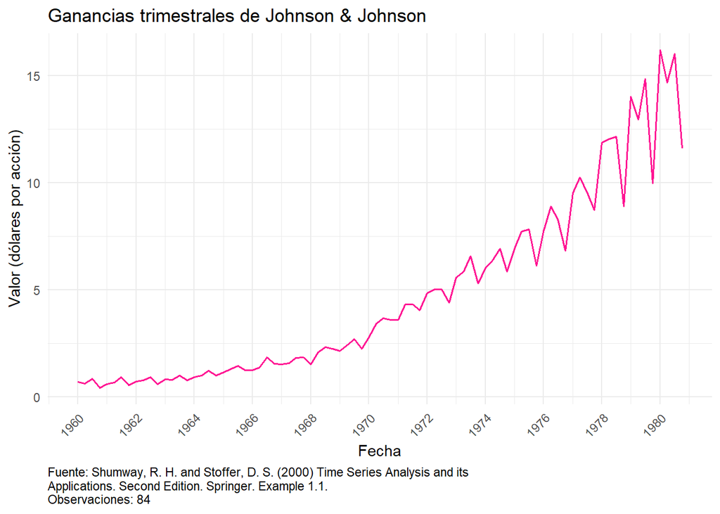

```r
# 2. Patrón de la Serie
g_serie <- graficar_serie(datos, "Ganancias trimestrales de Johnson & Johnson")
ggsave("figs/e7-serie.png", g_serie, width = 8, height = 4.5)
g_serie
```

**Mostrar/ocultar código**

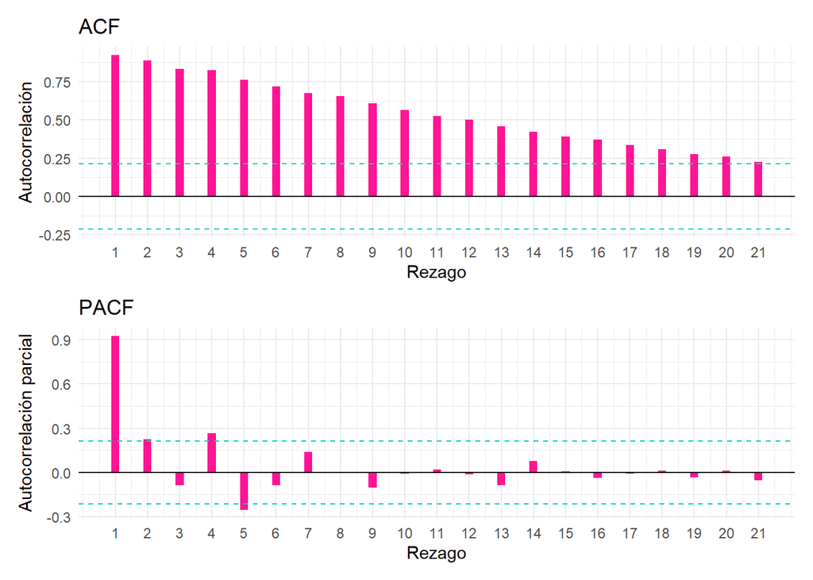

```r
g_corr <- correlograma(datos)
ggsave("figs/e7-correlograma.png", g_corr, width = 8, height = 6)
g_corr
```

Se observa una clara tendencia creciente en la serie, acompañada de un patrón que se vuelve cada vez más pronunciado a medida que transcurren los trimestres. Por su parte, aunque en el correlograma no se identifican picos prominentes en los múltiplos estacionales, se evidencia que casi todos los rezagos superan las bandas de significancia, lo que permite sospechar la presencia de autocorrelación y la falta de estacionariedad en la serie.

**Contraste**

**Mostrar/ocultar código**

```r
m <- min(floor(n / 4), 24)
r <- acf_manual(y, m)
limite <- qnorm(0.975) / sqrt(n)

contraste <- data.frame(rezago = 1:m, rh = r, z = r * sqrt(n), fuera_de_banda = abs(r) > limite)

formatear_tabla(data.frame(banda = limite, r1 = r[1], rezagos_fuera = sum(contraste$fuera_de_banda), esperados_por_azar = 0.05 * m), "Resumen del Contraste")
```

Resumen del Contraste

| banda | r1 | rezagos_fuera | esperados_por_azar |
| --- | --- | --- | --- |
| 0.2138 | 0.9251 | 21 | 1.05 |

**Mostrar/ocultar código**

```r
formatear_tabla(contraste[contraste$fuera_de_banda, ], "Rezagos Fuera de Banda")
```

Rezagos Fuera de Banda

| rezago | rh | z | fuera_de_banda |
| --- | --- | --- | --- |
| 1 | 0.9251 | 8.4787 | TRUE |
| 2 | 0.8883 | 8.1411 | TRUE |
| 3 | 0.8328 | 7.6332 | TRUE |
| 4 | 0.8241 | 7.5528 | TRUE |
| 5 | 0.7638 | 7.0003 | TRUE |
| 6 | 0.7176 | 6.5769 | TRUE |
| 7 | 0.6750 | 6.1867 | TRUE |
| 8 | 0.6544 | 5.9973 | TRUE |
| 9 | 0.6083 | 5.5755 | TRUE |
| 10 | 0.5642 | 5.1705 | TRUE |
| 11 | 0.5256 | 4.8168 | TRUE |
| 12 | 0.5004 | 4.5864 | TRUE |
| 13 | 0.4561 | 4.1798 | TRUE |
| 14 | 0.4227 | 3.8737 | TRUE |
| 15 | 0.3903 | 3.5771 | TRUE |
| 16 | 0.3699 | 3.3905 | TRUE |
| 17 | 0.3343 | 3.0635 | TRUE |
| 18 | 0.3066 | 2.8103 | TRUE |
| 19 | 0.2778 | 2.5464 | TRUE |
| 20 | 0.2603 | 2.3859 | TRUE |
| 21 | 0.2260 | 2.0717 | TRUE |

Al evaluar los primeros 21 rezagos en el correlograma, se evidencia que los 21 se encuentran por fuera de las bandas de significancia. Este resultado señala la presencia de autocorrelación en la serie y confirma la fuerte dependencia lineal que existe entre las observaciones a lo largo del tiempo.

**Ljung Box**

**Mostrar/ocultar código**

```r
lb_serie <- ljung_box(r, n, m, 0)
mostrar_prueba_html("Ljung-Box sobre la serie (p = 0)",
               "todas las autocorrelaciones hasta m son cero", "alguna es distinta de cero",
               paste0("chi2 con ", lb_serie$gl, " g.l."), lb_serie)
```

Prueba de Hipótesis: Ljung-Box sobre la serie (p = 0)

| H0 | todas las autocorrelaciones hasta m son cero |
| --- | --- |
| H1 | alguna es distinta de cero |
| Estadístico | 685.35 |
| Distribución | chi2 con 21 g.l. |
| Valor Crítico 5% | 32.671 |
| Valor p | 1.65e-131 |
| Decisión | se rechaza H0 al 5% |

**Mostrar/ocultar código**

```r
verificar_ljung_box(y, m)
```

```
Ljung-Box (m = 21 , p = 0 )
   Q propio: 685.3507039 | Q de R: 685.3507039
```

Con un valor p inferior a cualquier nivel de significancia , se rechaza la hipótesis nula. Por lo tanto, existe evidencia estadística suficiente para sugerir la presencia de autocorrelación en la serie, confirmando lo observado tanto en el correlograma como en el contraste de los rezagos.

**Partición**

**Mostrar/ocultar código**

```r
h <- min(12, floor(0.2 * n))
n_est <- n - h
y_est <- y[1:n_est]
y_val <- y[(n_est + 1):n]

formatear_tabla(data.frame(h = h, estimacion = n_est, validacion = h), "Partición de la Serie")
```

Partición de la Serie

| h | estimacion | validacion |
| --- | --- | --- |
| 12 | 72 | 12 |

La serie se dividió en dos conjuntos: un periodo de entrenamiento compuesto por 72 observaciones para la estimación del modelo y un conjunto de validación de 12 observaciones para evaluar su desempeño en el pronóstico fuera de muestra.

## 7.2 Método

Tal como se evidenciaba en el gráfico preliminar, la serie presenta una clara tendencia con una aceleración que sugiere un comportamiento de tipo exponencial. Por lo tanto, se decidió utilizar un modelo de tendencia exponencial para capturar adecuadamente esta dinámica de crecimiento a lo largo del tiempo

**Medidas**

**Mostrar/ocultar código**

```r
# 3. Ajuste (exponencial)
ajuste <- ajustar_tendencia(y_est, "exponencial")
p <- 2

pron <- ajuste$pronosticar(h)
pron_ing <- ingenuo(y_est, h)

tabla <- rbind(
  data.frame(caso = "Método, un paso (estimación)", medidas(y_est, ajuste$yhat, y_est)),
  data.frame(caso = "Método, h pasos (validación)", medidas(y_val, pron, y_est)),
  data.frame(caso = "Ingenuo, h pasos (validación)", medidas(y_val, pron_ing, y_est)))
formatear_tabla(tabla, "Medidas y Comparación")
```

Medidas y Comparación

| caso | MSE | MAD | MAPE | MASE | n |
| --- | --- | --- | --- | --- | --- |
| Método, un paso (estimación) | 0.3222 | 0.3637 | 11.8986 | 0.8160 | 72 |
| Método, h pasos (validación) | 7.7384 | 1.8450 | 16.5379 | 4.1401 | 12 |
| Ingenuo, h pasos (validación) | 22.5328 | 4.2150 | 30.4578 | 9.4584 | 12 |

**Validación Errores**

**Mostrar/ocultar código**

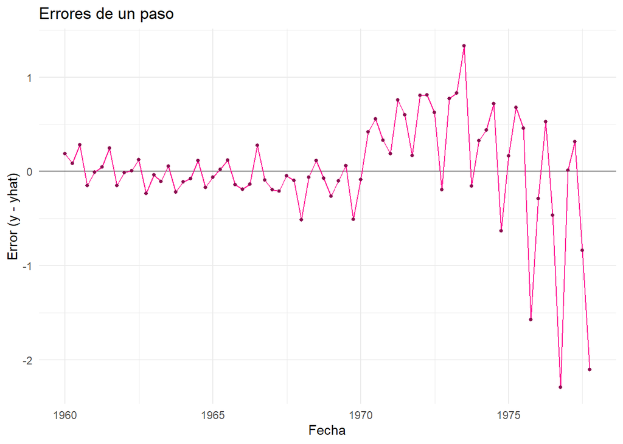

```r
# 4. Errores de un paso
errores <- y_est - ajuste$yhat
ve <- validar_errores(errores, p = p, fechas = datos$fecha[1:n_est])

ggsave("figs/e7-errores.png", ve$grafico_errores, width = 8, height = 3.5)
ggsave("figs/e7-correlograma-errores.png", ve$correlograma, width = 8, height = 6)

ve$grafico_errores
```

**Mostrar/ocultar código**

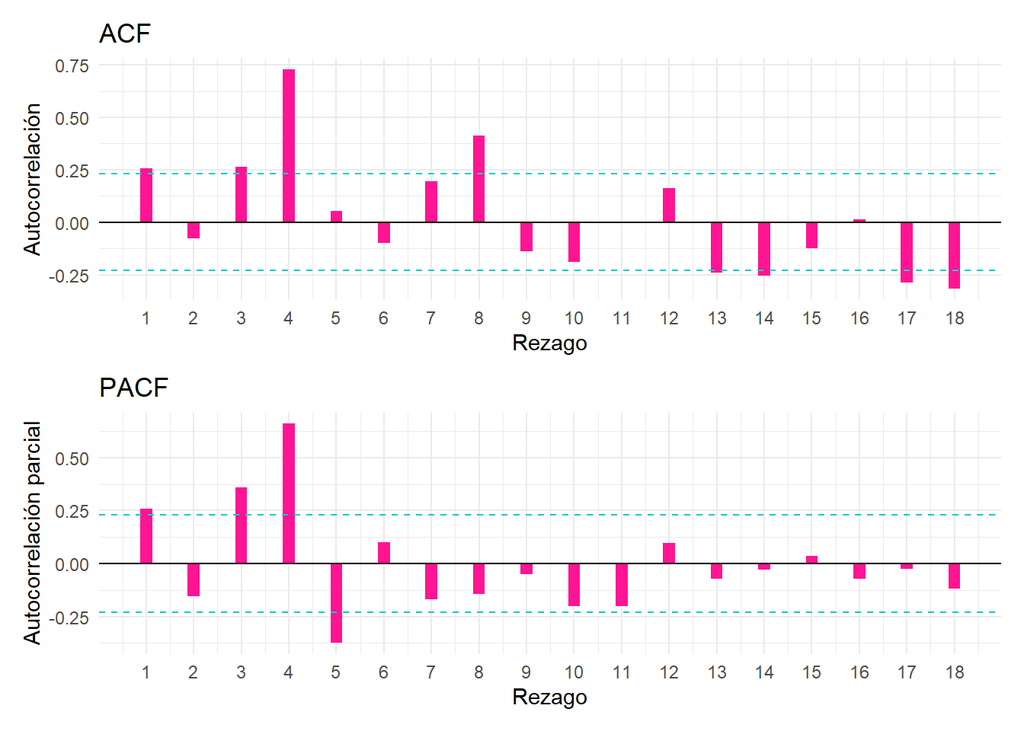

```r
ve$correlograma
```

En la gráfica de los errores se evidencia que, aunque estos oscilan alrededor de cero, su variabilidad aumenta drásticamente con el paso del tiempo, registrando valores bastante alejados en los últimos trimestres de la muestra. Por su parte, el correlograma muestra picos muy sobresalientes que superan ampliamente las bandas de referencia. Por tanto, es posible concluir que los errores no se comportan como ruido blanco.

**Pruebas**

**Mostrar/ocultar código**

```r
mostrar_prueba_html("t de media cero", "E[e] = 0", "E[e] distinto de 0", paste0("t con ", ve$prueba_t$gl, " g.l."), ve$prueba_t)
```

Prueba de Hipótesis: t de media cero

| H0 | E[e] = 0 |
| --- | --- |
| H1 | E[e] distinto de 0 |
| Estadístico | 0.20899 |
| Distribución | t con 71 g.l. |
| Valor Crítico 5% | 1.9939 |
| Valor p | 0.835 |
| Decisión | no se rechaza H0 al 5% |

**Mostrar/ocultar código**

```r
mostrar_prueba_html("Ljung-Box sobre los errores", "no hay autocorrelación hasta m", "hay autocorrelación", paste0("chi2 con ", ve$ljung_box$gl, " g.l. (m - p)"), ve$ljung_box)
```

Prueba de Hipótesis: Ljung-Box sobre los errores

| H0 | no hay autocorrelación hasta m |
| --- | --- |
| H1 | hay autocorrelación |
| Estadístico | 108.6 |
| Distribución | chi2 con 16 g.l. (m - p) |
| Valor Crítico 5% | 26.296 |
| Valor p | 8.28e-16 |
| Decisión | se rechaza H0 al 5% |

**Mostrar/ocultar código**

```r
mostrar_prueba_html("Jarque-Bera", "los errores son normales", "los errores no son normales", "chi2 con 2 g.l. (asintótica)", ve$jarque_bera, nota = if (ve$n < 20) paste("solo hay", ve$n, "errores (< 20): la decisión es poco fiable"))
```

Prueba de Hipótesis: Jarque-Bera

| H0 | los errores son normales |
| --- | --- |
| H1 | los errores no son normales |
| Estadístico | 111.53 |
| Distribución | chi2 con 2 g.l. (asintótica) |
| Valor Crítico 5% | 5.9915 |
| Valor p | 6.05e-25 |
| Decisión | se rechaza H0 al 5% |

**Mostrar/ocultar código**

```r
mostrar_prueba_html("Durbin-Watson", "no hay autocorrelación de primer orden", "hay autocorrelación de primer orden", "d entre 0 y 4", ve$durbin_watson)
```

Prueba de Hipótesis: Durbin-Watson

| H0 | no hay autocorrelación de primer orden |
| --- | --- |
| H1 | hay autocorrelación de primer orden |
| Estadístico | 1.2914 |
| Distribución | d entre 0 y 4 |
| Valor Crítico 5% | no aplica |
| Valor p | no aplica |
| Decisión | se compara con las cotas dL y dU de la tabla |

**t de media cero:** Con un valor p de 0.835, no se rechaza la hipótesis nula, lo que indica que no hay evidencia suficiente para sugerir que existe un sesgo en los errores.

**Ljung-Box:** Con un valor p menor a cualquier nivel de significancia , se rechaza la hipótesis nula; es decir, hay evidencia suficiente para sugerir la presencia de autocorrelación, lo cual tiene mucho sentido con lo observado en el correlograma.

**Jarque-Bera:** Con un valor p menor a cualquier nivel de significancia , se rechaza la hipótesis nula, por lo que hay evidencia suficiente para sugerir que los errores no siguen una distribución normal.

**Coeficientes y prueba t**

**Mostrar/ocultar código**

```r
coef <- ajuste$parametros$tabla
gl <- ajuste$parametros$n - nrow(coef)
formatear_tabla(coef, "Coeficientes de Regresión Exponencial (sobre ln y)")
```

Coeficientes de Regresión Exponencial (sobre ln y)

|  | estimacion | ee_ordinario | ee_robusto | t_ordinario | p_ordinario | t_robusto | p_robusto |
| --- | --- | --- | --- | --- | --- | --- | --- |
| a | -0.6968 | 0.0360 | 0.0426 | -19.3737 | 0 | -16.3663 | 0 |
| teta | 0.0428 | 0.0009 | 0.0010 | 49.9431 | 0 | 42.9616 | 0 |

**Mostrar/ocultar código**

```r
for (j in 1:nrow(coef)) {
  res <- list(estadistico = coef$t_robusto[j], valor_critico = qt(0.975, gl), valor_p = coef$p_robusto[j])
  mostrar_prueba_html(paste("t sobre", rownames(coef)[j], "(error estándar robusto)"),
                 paste(rownames(coef)[j], "= 0"), paste(rownames(coef)[j], "distinto de 0"),
                 paste0("t con ", gl, " g.l."), res)
}
```

La tasa de crecimiento estimada es de 0.04277, lo que equivale a un incremento continuo promedio en las ganancias por acción del 4.28% trimestral. Al evaluar las pruebas individuales t, en ambos casos se rechaza la hipótesis nula, confirmando que tanto el intercepto como la tasa de crecimiento son estadísticamente significativos.

Al comparar los errores estándar ordinarios con los robustos, se observa una diferencia importante entre ambos, lo cual confirma nuevamente la existencia de autocorrelación en los residuos que se había probado en los análisis anteriores.

### 7.2.1 Gráfico Final

**Mostrar/ocultar código**

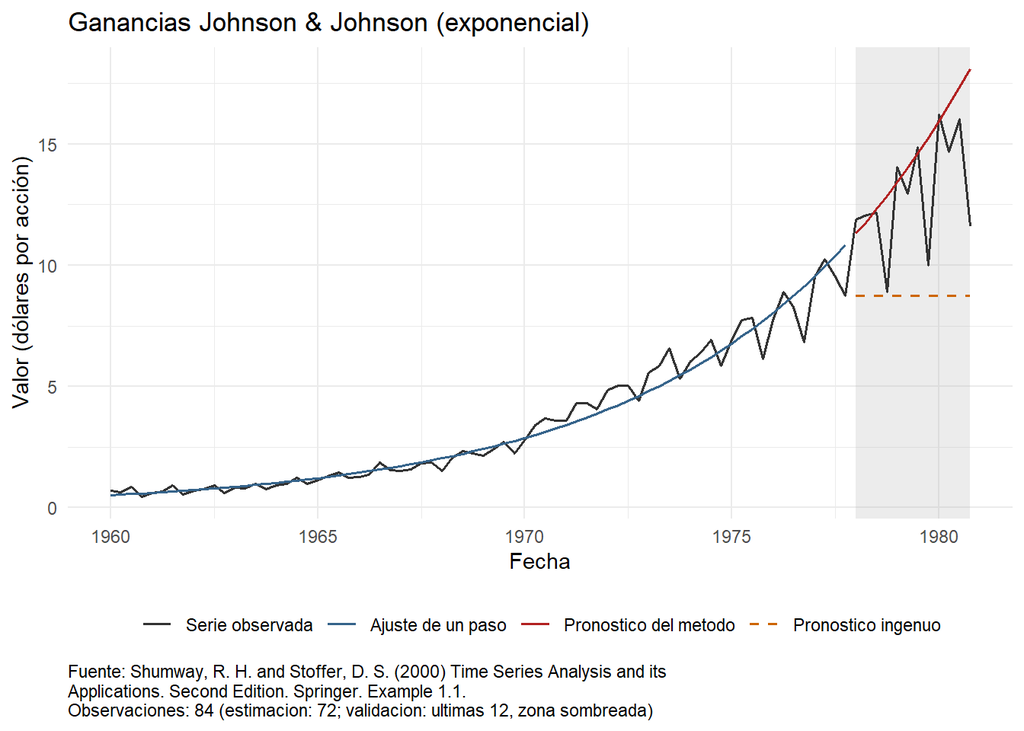

```r
g_final <- grafico_pronostico(datos, n_est, ajuste$yhat, pron, "Ganancias Johnson & Johnson (exponencial)", ingenuo = pron_ing)
ggsave("figs/e7-final.png", g_final, width = 8, height = 4.5)
g_final
```

En la figura se observa cómo el modelo se ajusta de forma precisa a la serie, logrando capturar adecuadamente el patrón de crecimiento exponencial a lo largo del tiempo. En contraste, el pronóstico ingenuo resulta inadecuado, ya que al ignorar la dinámica de la serie proyecta una línea horizontal plana muy por debajo de los valores observados en la zona de validación. Sin embargo, en la proyección del método exponencial se evidencia que, aunque acompaña de cerca la tendencia ascendente de los datos, no logra captar el patrón estacional recurrente que presenta la serie.

El modelo presenta un ajuste visual muy adecuado debido a que logra capturar con precisión la tendencia principal de crecimiento a largo plazo. Sin embargo, los errores no se comportan como ruido blanco porque el modelo de tendencia simple no incorpora la estructura estacional. Al ignorar estos patrones las desviaciones entre lo observado y lo estimado quedan autocorrelacionadas.

**Recomendaciones:** Le sirve a inversionistas que quieren calcular cuánto dinero va a ganar una empresa exitosa a largo plazo entendiendo que las ganancias se multiplican con el tiempo. Se recomienda usarlo solo para periodos cortos de 1 a 4 trimestres si se busca precisión. Su gran limitante es que ignora por completo las subidas y bajadas típicas de cada época del año (como vender más en un trimestre que en otro), dejando un margen de error del 16%.

# 8 Ejemplo 8: Holt Lineal

La serie registra la población residente en Australia expresada en miles de personas, correspondiente al conjunto de datos `austres` en R. Cuenta con un total de 89 observaciones trimestrales (frecuencia 4), abarcando desde abril de 1971 hasta abril de 1993. Los datos provienen de la publicación de Brockwell y Davis (1996) sobre análisis de series de tiempo.

**Mostrar/ocultar código**

```r
# 1. Descripción
fuente <- fuente_help("austres")
datos <- leer_serie(austres, fuente, "miles de residentes")
n <- nrow(datos)
y <- datos$y

stopifnot(n == length(austres), all(y == as.numeric(austres)))

df_desc <- data.frame(
  Propiedad = c("Nombre en R", "Fuente", "Unidad", "Frecuencia", "Rango Fechas", "Observaciones"),
  Detalle = c("austres", fuente, "miles de residentes",
              attr(datos, "frecuencia"),
              paste(format(min(datos$fecha)), "a", format(max(datos$fecha))),
              as.character(n))
)
formatear_tabla(df_desc, "1. DESCRIPCIÓN - Ejemplo 8")
```

1. DESCRIPCIÓN - Ejemplo 8

| Propiedad | Detalle |
| --- | --- |
| Nombre en R | austres |
| Fuente | P. J. Brockwell and R. A. Davis (1996) Introduction to Time Series and Forecasting. Springer |
| Unidad | miles de residentes |
| Frecuencia | 4 |
| Rango Fechas | 1971-04-01 a 1993-04-01 |
| Observaciones | 89 |

## 8.1 Patrón de la Serie

**Gráficos**

**Mostrar/ocultar código**

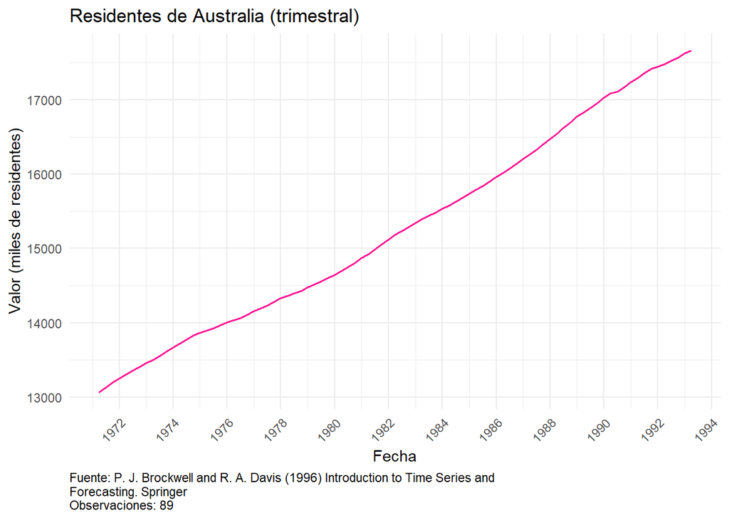

```r
# 2. Patrón de la Serie
g_serie <- graficar_serie(datos, "Residentes de Australia (trimestral)")
ggsave("figs/e8-serie.png", g_serie, width = 8, height = 4.5)
g_serie
```

**Mostrar/ocultar código**

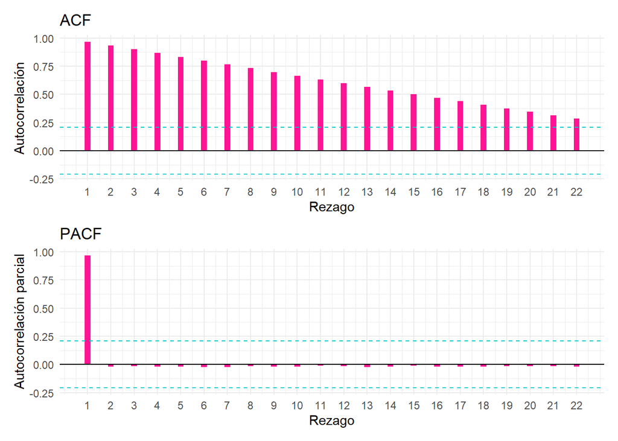

```r
g_corr <- correlograma(datos)
ggsave("figs/e8-correlograma.png", g_corr, width = 8, height = 6)
g_corr
```

La serie exhibe una clara tendencia creciente con una trayectoria prácticamente rectilínea a lo largo del tiempo. Este comportamiento se confirma en el correlograma (ACF) mediante un decrecimiento lento hacia cero a medida que aumentan los rezagos. Asimismo, en la función de autocorrelación parcial (PACF), el primer rezago alcanza un valor cercano a 1, lo que señala la falta de estacionariedad en media de la serie.

**Contraste**

**Mostrar/ocultar código**

```r
m <- min(floor(n / 4), 24)
r <- acf_manual(y, m)
limite <- qnorm(0.975) / sqrt(n)

contraste <- data.frame(rezago = 1:m, rh = r, z = r * sqrt(n), fuera_de_banda = abs(r) > limite)

formatear_tabla(data.frame(banda = limite, r1 = r[1], rezagos_fuera = sum(contraste$fuera_de_banda), esperados_por_azar = 0.05 * m), "Resumen del Contraste")
```

Resumen del Contraste

| banda | r1 | rezagos_fuera | esperados_por_azar |
| --- | --- | --- | --- |
| 0.2078 | 0.9666 | 22 | 1.1 |

**Mostrar/ocultar código**

```r
formatear_tabla(contraste[contraste$fuera_de_banda, ], "Rezagos Fuera de Banda")
```

Rezagos Fuera de Banda

| rezago | rh | z | fuera_de_banda |
| --- | --- | --- | --- |
| 1 | 0.9666 | 9.1188 | TRUE |
| 2 | 0.9330 | 8.8023 | TRUE |
| 3 | 0.8998 | 8.4886 | TRUE |
| 4 | 0.8665 | 8.1742 | TRUE |
| 5 | 0.8330 | 7.8584 | TRUE |
| 6 | 0.7993 | 7.5405 | TRUE |
| 7 | 0.7654 | 7.2209 | TRUE |
| 8 | 0.7317 | 6.9030 | TRUE |
| 9 | 0.6982 | 6.5866 | TRUE |
| 10 | 0.6647 | 6.2709 | TRUE |
| 11 | 0.6318 | 5.9604 | TRUE |
| 12 | 0.5993 | 5.6534 | TRUE |
| 13 | 0.5665 | 5.3439 | TRUE |
| 14 | 0.5339 | 5.0371 | TRUE |
| 15 | 0.5020 | 4.7360 | TRUE |
| 16 | 0.4702 | 4.4363 | TRUE |
| 17 | 0.4385 | 4.1372 | TRUE |
| 18 | 0.4069 | 3.8390 | TRUE |
| 19 | 0.3759 | 3.5462 | TRUE |
| 20 | 0.3453 | 3.2578 | TRUE |
| 21 | 0.3152 | 2.9738 | TRUE |
| 22 | 0.2853 | 2.6917 | TRUE |

Al evaluar los primeros 22 rezagos en el correlograma, se observa que la totalidad de ellos (22) se encuentran por fuera de las bandas de significancia. Este comportamiento refleja la presencia de una autocorrelación extremadamente fuerte en la serie, confirmando una elevada dependencia lineal entre las observaciones a lo largo de los trimestres evaluados.

**Ljung Box**

**Mostrar/ocultar código**

```r
lb_serie <- ljung_box(r, n, m, 0)
mostrar_prueba_html("Ljung-Box sobre la serie (p = 0)",
               "todas las autocorrelaciones hasta m son cero", "alguna es distinta de cero",
               paste0("chi2 con ", lb_serie$gl, " g.l."), lb_serie)
```

Prueba de Hipótesis: Ljung-Box sobre la serie (p = 0)

| H0 | todas las autocorrelaciones hasta m son cero |
| --- | --- |
| H1 | alguna es distinta de cero |
| Estadístico | 938.95 |
| Distribución | chi2 con 22 g.l. |
| Valor Crítico 5% | 33.924 |
| Valor p | 1.88e-184 |
| Decisión | se rechaza H0 al 5% |

**Mostrar/ocultar código**

```r
verificar_ljung_box(y, m)
```

```
Ljung-Box (m = 22 , p = 0 )
   Q propio: 938.9522206 | Q de R: 938.9522206
```

El valor p es menor que cualquier nivel de significancia , por lo que se rechaza la hipótesis nula. Esto proporciona evidencia suficiente para sugerir la presencia de autocorrelación en la serie, confirmando lo observado tanto en el conteo de rezagos fuera de las bandas como en el comportamiento del correlograma.

**Partición**

**Mostrar/ocultar código**

```r
h <- min(12, floor(0.2 * n))
n_est <- n - h
y_est <- y[1:n_est]
y_val <- y[(n_est + 1):n]

formatear_tabla(data.frame(h = h, estimacion = n_est, validacion = h), "Partición de la Serie")
```

Partición de la Serie

| h | estimacion | validacion |
| --- | --- | --- |
| 12 | 77 | 12 |

La serie se dividió en un conjunto de entrenamiento de 77 observaciones trimestrales para la estimación del modelo y un conjunto de validación de 12 datos para evaluar la capacidad predictiva de las estimaciones.

## 8.2 Método

Para esta serie se seleccionó el método de Holt Lineal. Este enfoque permite actualizar dinámicamente tanto el nivel como la pendiente de la serie a medida que se incorporan nuevas observaciones, adaptándose de manera flexible a los cambios en la tendencia a lo largo del tiempo.

**Optimización**

**Mostrar/ocultar código**

```r
# 3. Ajuste (holt)
opt <- optimizar(y_est, "holt")
formatear_tabla(cbind(opt$optimo, en_borde = opt$en_borde), "4. AJUSTE (holt) - Optimización")
```

4. AJUSTE (holt) - Optimización

| alpha | beta | mse | en_borde |
| --- | --- | --- | --- |
| 0.95 | 0.8 | 129.3284 | TRUE |

**Mostrar/ocultar código**

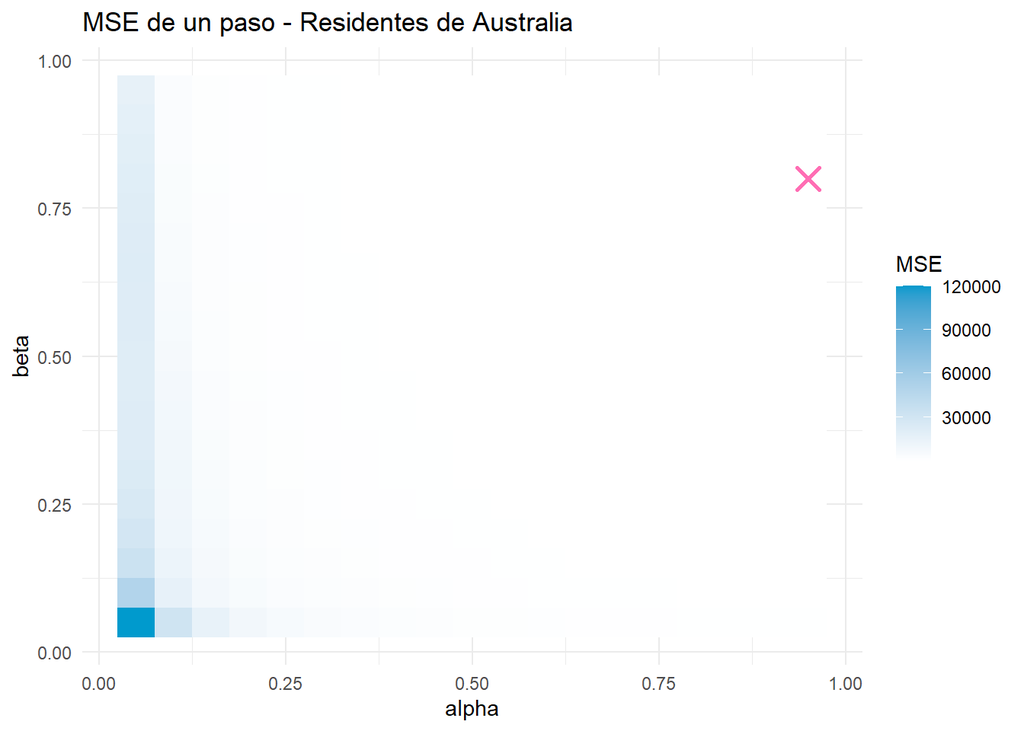

```r
g_opt <- grafico_mse(opt, "MSE de un paso - Residentes de Australia")
ggsave("figs/e8-optimizacion.png", g_opt, width = 7, height = 5)
g_opt
```

**Mostrar/ocultar código**

```r
interpretar_borde(opt)
```

```
  El optimo cae en el borde superior de alpha: equivale al pronostico ingenuo y senala que la serie no es estacionaria en media.
```

**Mostrar/ocultar código**

```r
ajuste <- ajustar_holt(y_est, opt$optimo$alpha, opt$optimo$beta)
```

La optimización del modelo arrojó un parámetro de nivel α=0.95, lo que indica que se otorga un peso predominante a las observaciones más recientes, dando una baja relevancia al historial pasado de la serie. Por su parte, el parámetro de tendencia $β=0.80$señala que la pendiente reacciona de manera rápida ante los cambios en la velocidad de crecimiento, lo que permite al modelo adaptar dinámicamente su inclinación a las fluctuaciones recientes de los datos. En el mapa de calor se observa que el error es alto solo en la esquina donde tanto alfa como beta son muy bajos (el recuadro oscuro), es decir, cuando el modelo reacciona muy poco tanto al nivel como a la tendencia; en el resto de la rejilla el error cae con fuerza y se mantiene bajo, con la combinación elegida ubicada justo en esa zona de menor error. Cabe señalar que $α=0.95$ corresponde al límite superior del rango evaluado, lo cual equivale casi al pronóstico ingenuo y es una señal de que la serie no es estacionaria en media, es decir, tiene una tendencia marcada que el modelo necesita seguir de cerca para pronosticar bien.

**Medidas**

**Mostrar/ocultar código**

```r
p <- 2

pron <- ajuste$pronosticar(h)
pron_ing <- ingenuo(y_est, h)

tabla <- rbind(
  data.frame(caso = "Método, un paso (estimación)", medidas(y_est, ajuste$yhat, y_est)),
  data.frame(caso = "Método, h pasos (validación)", medidas(y_val, pron, y_est)),
  data.frame(caso = "Ingenuo, h pasos (validación)", medidas(y_val, pron_ing, y_est)))
formatear_tabla(tabla, "Medidas y Comparación")
```

Medidas y Comparación

| caso | MSE | MAD | MAPE | MASE | n |
| --- | --- | --- | --- | --- | --- |
| Método, un paso (estimación) | 129.3284 | 7.5298 | 0.0514 | 0.1424 | 76 |
| Método, h pasos (validación) | 8207.2350 | 78.4718 | 0.4486 | 1.4842 | 12 |
| Ingenuo, h pasos (validación) | 133004.7908 | 322.0417 | 1.8405 | 6.0912 | 12 |

Al comparar las medidas de precisión entre ambos métodos, queda muy claro que el modelo de Holt Lineal presenta un desempeño muy superior al pronóstico ingenuo. El MSE registra un valor de 8207 frente a 133004.8 del ingenuo, lo que muestra que en promedio se cometen menos errores. De igual manera, la desviación absoluta (MAD) indica que el modelo se equivoca en promedio en solo 78 unidades, mientras que el pronóstico de referencia supera más del doble este margen. En términos porcentuales (MAPE), las estimaciones se alejan tan solo un 0.4% de los valores reales, frente a un 1.8% del método ingenuo. Por último, el resultado del MASE confirma que el modelo de Holt Lineal proporciona una precisión de pronóstico significativamente mejor.

**Validación Errores**

**Mostrar/ocultar código**

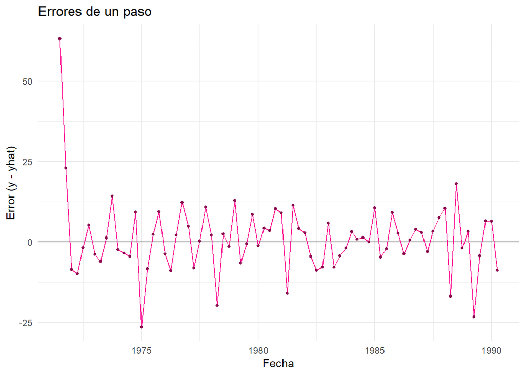

```r
# 4. Errores de un paso
errores <- y_est - ajuste$yhat
ve <- validar_errores(errores, p = p, fechas = datos$fecha[1:n_est])

ggsave("figs/e8-errores.png", ve$grafico_errores, width = 8, height = 3.5)
ggsave("figs/e8-correlograma-errores.png", ve$correlograma, width = 8, height = 6)

ve$grafico_errores
```

**Mostrar/ocultar código**

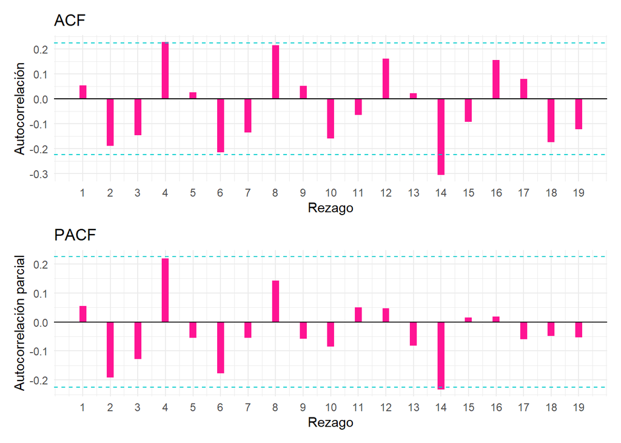

```r
ve$correlograma
```

En la gráfica de los errores se observa cómo estos oscilan alrededor de cero, aunque se aprecian algunos puntos relativamente alejados. En general, no se identifican patrones o tendencias evidentes en su comportamiento a lo largo del tiempo. Por su parte, el correlograma muestra que la mayoría de los rezagos se encuentran dentro de las bandas de significancia, si bien existen dos rezagos que sobresalen ligeramente por fuera de los límites, lo cual podría sugerir la presencia de cierta autocorrelación en los residuos.

**Pruebas**

**Mostrar/ocultar código**

```r
mostrar_prueba_html("t de media cero", "E[e] = 0", "E[e] distinto de 0", paste0("t con ", ve$prueba_t$gl, " g.l."), ve$prueba_t)
```

Prueba de Hipótesis: t de media cero

| H0 | E[e] = 0 |
| --- | --- |
| H1 | E[e] distinto de 0 |
| Estadístico | 0.82041 |
| Distribución | t con 76 g.l. |
| Valor Crítico 5% | 1.9917 |
| Valor p | 0.415 |
| Decisión | no se rechaza H0 al 5% |

**Mostrar/ocultar código**

```r
mostrar_prueba_html("Ljung-Box sobre los errores", "no hay autocorrelación hasta m", "hay autocorrelación", paste0("chi2 con ", ve$ljung_box$gl, " g.l. (m - p)"), ve$ljung_box)
```

Prueba de Hipótesis: Ljung-Box sobre los errores

| H0 | no hay autocorrelación hasta m |
| --- | --- |
| H1 | hay autocorrelación |
| Estadístico | 41.947 |
| Distribución | chi2 con 17 g.l. (m - p) |
| Valor Crítico 5% | 27.587 |
| Valor p | 0.000683 |
| Decisión | se rechaza H0 al 5% |

**Mostrar/ocultar código**

```r
mostrar_prueba_html("Jarque-Bera", "los errores son normales", "los errores no son normales", "chi2 con 2 g.l. (asintótica)", ve$jarque_bera, nota = if (ve$n < 20) paste("solo hay", ve$n, "errores (< 20): la decisión es poco fiable"))
```

Prueba de Hipótesis: Jarque-Bera

| H0 | los errores son normales |
| --- | --- |
| H1 | los errores no son normales |
| Estadístico | 385.94 |
| Distribución | chi2 con 2 g.l. (asintótica) |
| Valor Crítico 5% | 5.9915 |
| Valor p | 1.57e-84 |
| Decisión | se rechaza H0 al 5% |

**Mostrar/ocultar código**

```r
mostrar_prueba_html("Durbin-Watson", "no hay autocorrelación de primer orden", "hay autocorrelación de primer orden", "d entre 0 y 4", ve$durbin_watson)
```

Prueba de Hipótesis: Durbin-Watson

| H0 | no hay autocorrelación de primer orden |
| --- | --- |
| H1 | hay autocorrelación de primer orden |
| Estadístico | 1.472 |
| Distribución | d entre 0 y 4 |
| Valor Crítico 5% | no aplica |
| Valor p | no aplica |
| Decisión | se compara con las cotas dL y dU de la tabla |

**t de media cero:** Con un valor p de 0.415, no se rechaza la hipótesis nula, lo que indica que no hay evidencia suficiente para sugerir la existencia de un sesgo en los errores, aspecto que se confirma en el análisis gráfico.

**Ljung-Box:** Con un valor p de 0.0006, se rechaza la hipótesis nula, por lo que hay evidencia suficiente para sugerir la presencia de autocorrelación en los residuos, algo que concuerda con lo observado en el correlograma.

**Jarque-Bera:** Con un valor p menor a cualquier nivel de significancia , se rechaza la hipótesis nula, lo que indica que existe evidencia suficiente para sugerir que los errores no siguen una distribución normal.

### 8.2.1 Gráfico Final

**Mostrar/ocultar código**

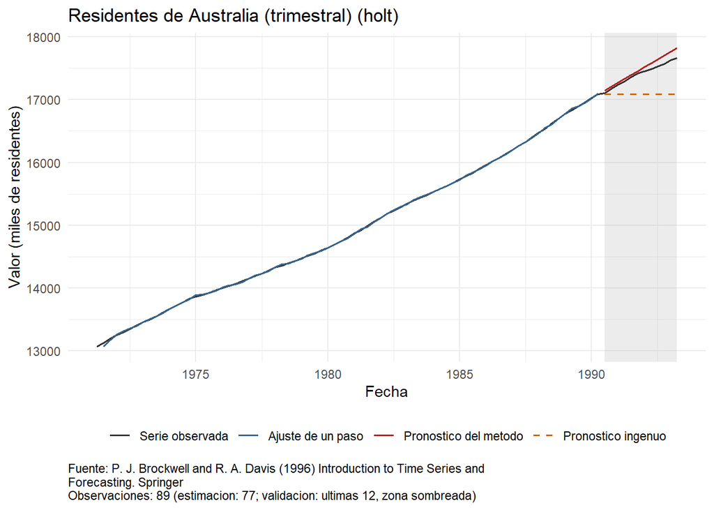

```r
g_final <- grafico_pronostico(datos, n_est, ajuste$yhat, pron, "Residentes de Australia (trimestral) (holt)", ingenuo = pron_ing)
ggsave("figs/e8-final.png", g_final, width = 8, height = 4.5)
g_final
```

En la figura se evidencia que el método de Holt Lineal logra captar correctamente el patrón general de la serie; además, demuestra su capacidad para adaptarse al cambio en la aceleración que se presenta en los últimos periodos. Esta flexibilidad permite que las proyecciones se acerquen de manera notable a la serie observada en la zona de validación. Por el contrario, el pronóstico ingenuo ofrece un rendimiento muy deficiente al ignorar la dinámica y las tendencias de la serie, proyectando una trayectoria plana incapaz de responder a los cambios observados en los datos.

Al comparar el desempeño obtenido en esta serie frente al modelo de tendencia lineal aplicado en la Serie 5, se evidencia que el método de Holt Lineal logra captar de forma significativamente superior el comportamiento de los datos. Esto se debe a su capacidad para adaptar dinámicamente tanto el nivel como la pendiente ante cambios en la velocidad de crecimiento, lo que permite generar proyecciones mucho más cercanas a los valores observados en el periodo de validación. En contraste, el modelo de tendencia lineal proyecta un ritmo de variación rígido y constante, lo que limita su capacidad de respuesta frente a desaceleraciones o cambios en la trayectoria de la serie.

**Recomendaciones:** Les sirve a analistas de demografía o salud pública que necesitan predecir la población futura con un método flexible que se acomode si el ritmo de crecimiento se acelera o se frena. Es muy confiable para usarse en un horizonte de 1 a 12 trimestres (3 años). Su límite es que, como le da un peso del 0.95 al dato más reciente, le da demasiada importancia a los cambios del último momento, manteniendo una diferencia promedio de 78 mil habitantes.

# 9 Contraejemplo: Holt Lineal sobre Serie Estacionaria

Para este análisis se empleó la serie `lynx`, la cual registra el número de linces atrapados en el área del río Mackenzie en Canadá (114 observaciones anuales, recopiladas entre 1821 y 1934; Brockwell & Davis, 1991)

**Mostrar/ocultar código**

```r
# 1. Descripción
fuente <- fuente_help("lynx")
datos <- leer_serie(lynx, fuente, "número de linces cazados")
n <- nrow(datos)
y <- datos$y

stopifnot(n == length(lynx), all(y == as.numeric(lynx)))

df_desc <- data.frame(
  Propiedad = c("Nombre en R", "Fuente", "Unidad", "Frecuencia", "Rango Fechas", "Observaciones"),
  Detalle = c("lynx", fuente, "número de linces cazados",
              attr(datos, "frecuencia"),
              paste(format(min(datos$fecha)), "a", format(max(datos$fecha))),
              as.character(n))
)
formatear_tabla(df_desc, "1. DESCRIPCIÓN - Contraejemplo")
```

1. DESCRIPCIÓN - Contraejemplo

| Propiedad | Detalle |
| --- | --- |
| Nombre en R | lynx |
| Fuente | Brockwell, P. J. and Davis, R. A. (1991). Time Series and Forecasting Methods. Second edition. Springer. Series G (page 557). |
| Unidad | número de linces cazados |
| Frecuencia | 1 |
| Rango Fechas | 1821-01-01 a 1934-01-01 |
| Observaciones | 114 |

## 9.1 Patrón de la Serie

**Gráficos**

**Mostrar/ocultar código**

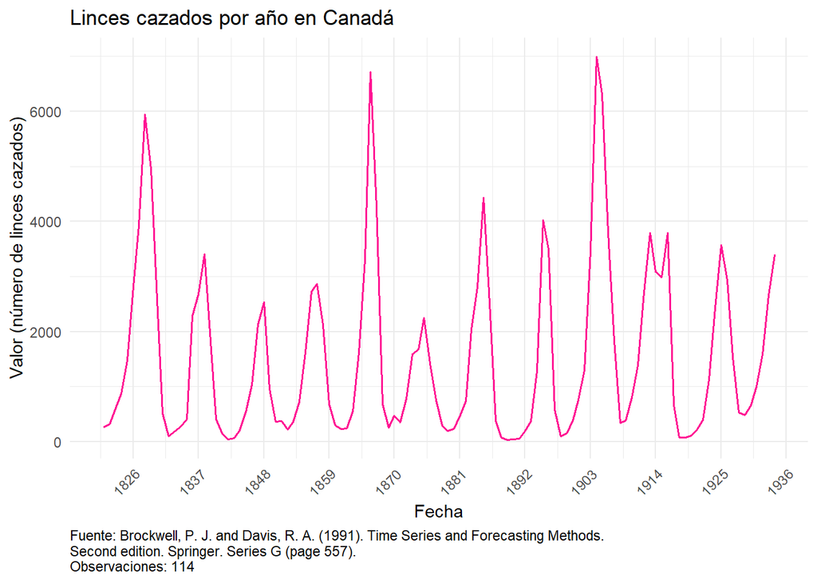

```r
# 2. Patrón de la Serie
g_serie <- graficar_serie(datos, "Linces cazados por año en Canadá")
ggsave("figs/contra-serie.png", g_serie, width = 8, height = 4.5)
g_serie
```

**Mostrar/ocultar código**

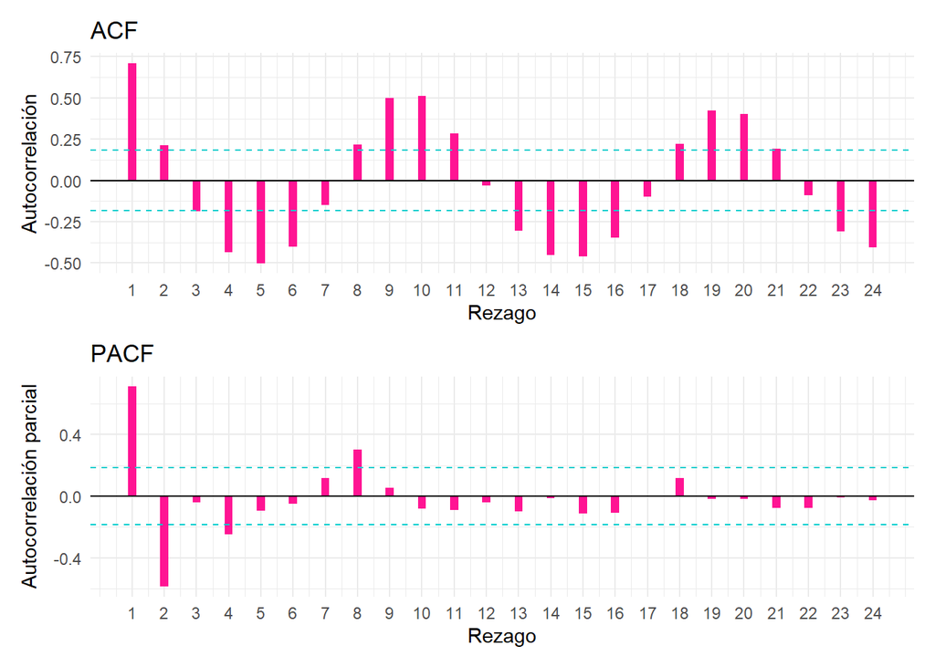

```r
g_corr <- correlograma(datos)
ggsave("figs/contra-correlograma.png", g_corr, width = 8, height = 6)
g_corr
```

En la gráfica de la serie se observa un comportamiento estacional pronunciado, en el que se repiten patrones claros a lo largo del tiempo. Esta estructura se refleja de manera evidente en el correlograma, donde se aprecian rezagos significativos que se repiten en múltiplos de manera periódica. Asimismo, la serie oscila sin mostrar un cambio de nivel o una dirección sostenida a largo plazo, lo que sugiere un comportamiento de naturaleza estacionaria.

**Contraste**

**Mostrar/ocultar código**

```r
m <- min(floor(n / 4), 24)
r <- acf_manual(y, m)
limite <- qnorm(0.975) / sqrt(n)

contraste <- data.frame(rezago = 1:m, rh = r, z = r * sqrt(n), fuera_de_banda = abs(r) > limite)

formatear_tabla(data.frame(banda = limite, r1 = r[1], rezagos_fuera = sum(contraste$fuera_de_banda), esperados_por_azar = 0.05 * m), "Resumen del Contraste")
```

Resumen del Contraste

| banda | r1 | rezagos_fuera | esperados_por_azar |
| --- | --- | --- | --- |
| 0.1836 | 0.7108 | 20 | 1.2 |

**Mostrar/ocultar código**

```r
formatear_tabla(contraste[contraste$fuera_de_banda, ], "Rezagos Fuera de Banda")
```

Rezagos Fuera de Banda

|  | rezago | rh | z | fuera_de_banda |
| --- | --- | --- | --- | --- |
| 1 | 1 | 0.7108 | 7.5895 | TRUE |
| 2 | 2 | 0.2144 | 2.2893 | TRUE |
| 3 | 3 | -0.1885 | -2.0129 | TRUE |
| 4 | 4 | -0.4335 | -4.6285 | TRUE |
| 5 | 5 | -0.5022 | -5.3622 | TRUE |
| 6 | 6 | -0.4003 | -4.2746 | TRUE |
| 8 | 8 | 0.2184 | 2.3315 | TRUE |
| 9 | 9 | 0.5009 | 5.3482 | TRUE |
| 10 | 10 | 0.5139 | 5.4870 | TRUE |
| 11 | 11 | 0.2834 | 3.0264 | TRUE |
| 13 | 13 | -0.3030 | -3.2357 | TRUE |
| 14 | 14 | -0.4499 | -4.8035 | TRUE |
| 15 | 15 | -0.4608 | -4.9198 | TRUE |
| 16 | 16 | -0.3461 | -3.6949 | TRUE |
| 18 | 18 | 0.2230 | 2.3813 | TRUE |
| 19 | 19 | 0.4256 | 4.5441 | TRUE |
| 20 | 20 | 0.4042 | 4.3161 | TRUE |
| 21 | 21 | 0.1940 | 2.0709 | TRUE |
| 23 | 23 | -0.3073 | -3.2806 | TRUE |
| 24 | 24 | -0.4035 | -4.3080 | TRUE |

Al evaluar los primeros 24 rezagos, se observa que 20 de ellos sobrepasan las bandas de significancia. Este resultado sugiere una clara presencia de autocorrelación en la serie, lo cual resulta completamente coherente con la estructura y los patrones identificados en los análisis gráficos previos.

**Ljung Box**

**Mostrar/ocultar código**

```r
lb_serie <- ljung_box(r, n, m, 0)
mostrar_prueba_html("Ljung-Box sobre la serie (p = 0)",
               "todas las autocorrelaciones hasta m son cero", "alguna es distinta de cero",
               paste0("chi2 con ", lb_serie$gl, " g.l."), lb_serie)
```

Prueba de Hipótesis: Ljung-Box sobre la serie (p = 0)

| H0 | todas las autocorrelaciones hasta m son cero |
| --- | --- |
| H1 | alguna es distinta de cero |
| Estadístico | 409.66 |
| Distribución | chi2 con 24 g.l. |
| Valor Crítico 5% | 36.415 |
| Valor p | 7.78e-72 |
| Decisión | se rechaza H0 al 5% |

**Mostrar/ocultar código**

```r
verificar_ljung_box(y, m)
```

```
Ljung-Box (m = 24 , p = 0 )
   Q propio: 409.6634364 | Q de R: 409.6634364
```

Con un valor p menor que cualquier $\alpha$ se rechaza $H_0$, es decir, hay autocorrelación, lo que confirma todo lo anterior

**Partición**

**Mostrar/ocultar código**

```r
h <- min(12, floor(0.2 * n))
n_est <- n - h
y_est <- y[1:n_est]
y_val <- y[(n_est + 1):n]

formatear_tabla(data.frame(h = h, estimacion = n_est, validacion = h), "Partición de la Serie")
```

Partición de la Serie

| h | estimacion | validacion |
| --- | --- | --- |
| 12 | 102 | 12 |

La serie se dividió en un conjunto de entrenamiento de 102 observaciones para la estimación de los parámetros del modelo, reservando las 12 observaciones restantes como muestra de validación para evaluar la capacidad de pronóstico fuera de muestra.

## 9.2 Método

Al tratarse de una serie estacional y estacionaria, se evaluará el comportamiento del método de Holt Lineal. El propósito es analizar cómo responde un modelo diseñado específicamente para capturar y proyectar componentes de nivel y tendencia cuando se aplica a una serie que no presenta una dirección o incremento constante en el tiempo.

**Optimización**

**Mostrar/ocultar código**

```r
# 3. Ajuste (holt)
opt <- optimizar(y_est, "holt")
formatear_tabla(cbind(opt$optimo, en_borde = opt$en_borde), "4. AJUSTE (holt) - Optimización")
```

4. AJUSTE (holt) - Optimización

| alpha | beta | mse | en_borde |
| --- | --- | --- | --- |
| 0.95 | 0.05 | 1619300 | TRUE |

**Mostrar/ocultar código**

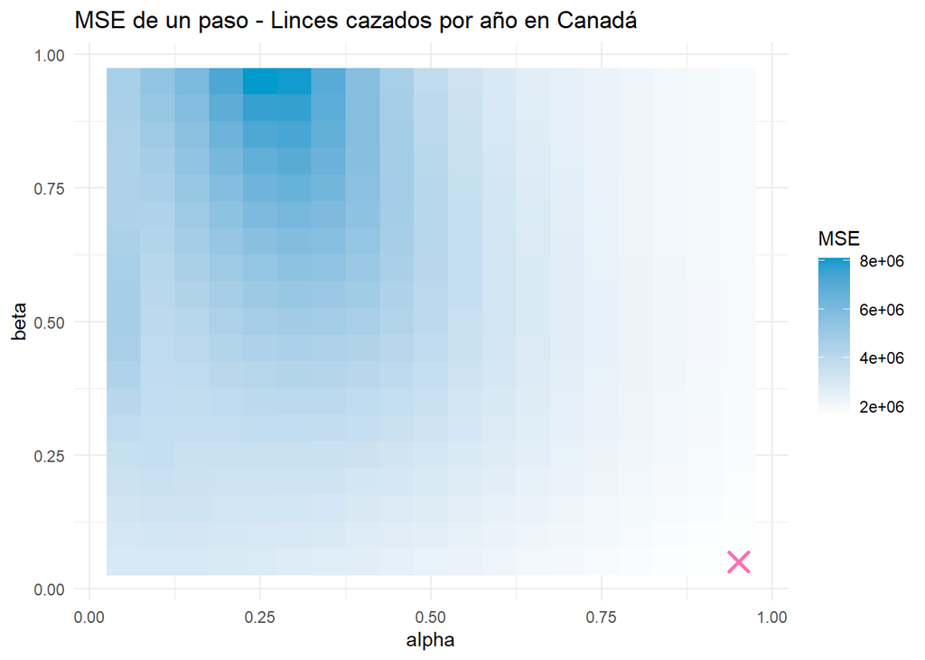

```r
g_opt <- grafico_mse(opt, "MSE de un paso - Linces cazados por año en Canadá")
ggsave("figs/contra-optimizacion.png", g_opt, width = 7, height = 5)
g_opt
```

**Mostrar/ocultar código**

```r
interpretar_borde(opt)
```

```
  El optimo cae en el borde superior de alpha: equivale al pronostico ingenuo y senala que la serie no es estacionaria en media.
```

**Mostrar/ocultar código**

```r
ajuste <- ajustar_holt(y_est, opt$optimo$alpha, opt$optimo$beta)
```

Sin embargo, tanto alfa como beta cayeron en los bordes del rango evaluado, y aquí eso no debe leerse como evidencia de una tendencia real: `lynx` es una serie estacionaria en media, con estacionalidad. Que Holt necesite un alfa tan alto para minimizar el error muestra justamente que el método está mal aplicado a esta serie: como no existe una tendencia que seguir, el modelo termina pegándose casi al último dato para intentar reaccionar a los saltos, en vez de capturar un patrón real. El beta tan bajo, por su parte, indica que la pendiente casi no se actualiza, lo que refuerza la idea de que el modelo no encuentra ninguna tendencia estable que ajustar.

**Medidas**

**Mostrar/ocultar código**

```r
p <- 2

pron <- ajuste$pronosticar(h)
pron_ing <- ingenuo(y_est, h)

tabla <- rbind(
  data.frame(caso = "Método, un paso (estimación)", medidas(y_est, ajuste$yhat, y_est)),
  data.frame(caso = "Método, h pasos (validación)", medidas(y_val, pron, y_est)),
  data.frame(caso = "Ingenuo, h pasos (validación)", medidas(y_val, pron_ing, y_est)))
formatear_tabla(tabla, "Medidas y Comparación")
```

Medidas y Comparación

| caso | MSE | MAD | MAPE | MASE | n |
| --- | --- | --- | --- | --- | --- |
| Método, un paso (estimación) | 1619300 | 889.2194 | 115.2990 | 1.0602 | 101 |
| Método, h pasos (validación) | 4627757 | 1848.0314 | 102.2177 | 2.2034 | 12 |
| Ingenuo, h pasos (validación) | 3202589 | 1428.4167 | 65.6585 | 1.7031 | 12 |

Al analizar las métricas de precisión fuera de muestra, se hace evidente que el pronóstico ingenuo presenta un mejor desempeño en comparación con el modelo de Holt Lineal, al registrar valores de error consistentemente menores. En particular, el error cuadrático medio (MSE) del Holt Lineal alcanza un valor de 4627757 frente a 3202589 del modelo ingenuo, lo que confirma que este último comete errores de menor magnitud en promedio. Asimismo, en términos absolutos (MAE), el pronóstico ingenuo se desvía en promedio 1428 unidades respecto a los valores reales, mientras que el Holt Lineal registra una desviación superior de 1848 unidades. Esta diferencia se mantiene en la escala porcentual (MAPE), donde el Holt Lineal se aleja un 102.2% de las observaciones reales frente al 65.66% del método ingenuo. Finalmente, la métrica MASE ratifica que el pronóstico ingenuo supera en rendimiento al modelo Holt Lineal en esta serie

**Validación Errores**

**Mostrar/ocultar código**

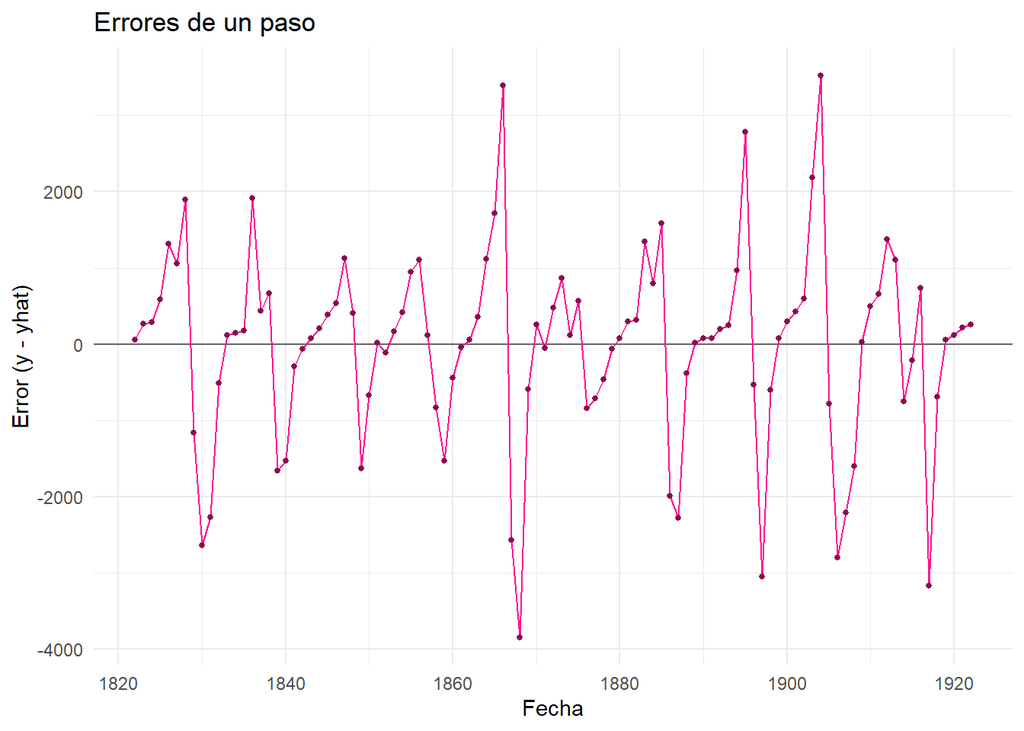

```r
# 4. Errores de un paso
errores <- y_est - ajuste$yhat
ve <- validar_errores(errores, p = p, fechas = datos$fecha[1:n_est])

ggsave("figs/contra-errores.png", ve$grafico_errores, width = 8, height = 3.5)
ggsave("figs/contra-correlograma-errores.png", ve$correlograma, width = 8, height = 6)

ve$grafico_errores
```

**Mostrar/ocultar código**

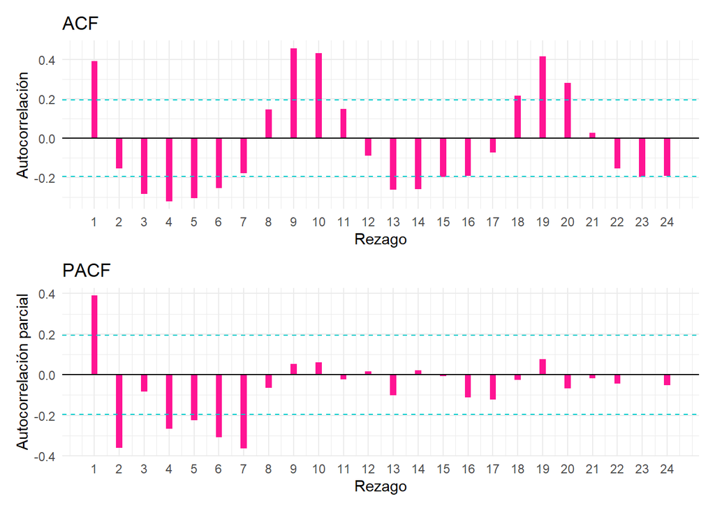

```r
ve$correlograma
```

En la inspección gráfica de los residuos se evidencia que estos continúan exhibiendo un patrón estructurado, lo que indica que el modelo no logró extraer toda la información de la serie. Esto se confirma en el correlograma, donde se observan varios rezagos que sobrepasan las bandas de significancia, destacándose además la presencia de rezagos prominentes en intervalos múltiplos

**Pruebas**

**Mostrar/ocultar código**

```r
mostrar_prueba_html("t de media cero", "E[e] = 0", "E[e] distinto de 0", paste0("t con ", ve$prueba_t$gl, " g.l."), ve$prueba_t)
```

Prueba de Hipótesis: t de media cero

| H0 | E[e] = 0 |
| --- | --- |
| H1 | E[e] distinto de 0 |
| Estadístico | -0.10304 |
| Distribución | t con 101 g.l. |
| Valor Crítico 5% | 1.9837 |
| Valor p | 0.918 |
| Decisión | no se rechaza H0 al 5% |

**Mostrar/ocultar código**

```r
mostrar_prueba_html("Ljung-Box sobre los errores", "no hay autocorrelación hasta m", "hay autocorrelación", paste0("chi2 con ", ve$ljung_box$gl, " g.l. (m - p)"), ve$ljung_box)
```

Prueba de Hipótesis: Ljung-Box sobre los errores

| H0 | no hay autocorrelación hasta m |
| --- | --- |
| H1 | hay autocorrelación |
| Estadístico | 187.9 |
| Distribución | chi2 con 22 g.l. (m - p) |
| Valor Crítico 5% | 33.924 |
| Valor p | 2.6e-28 |
| Decisión | se rechaza H0 al 5% |

**Mostrar/ocultar código**

```r
mostrar_prueba_html("Jarque-Bera", "los errores son normales", "los errores no son normales", "chi2 con 2 g.l. (asintótica)", ve$jarque_bera, nota = if (ve$n < 20) paste("solo hay", ve$n, "errores (< 20): la decisión es poco fiable"))
```

Prueba de Hipótesis: Jarque-Bera

| H0 | los errores son normales |
| --- | --- |
| H1 | los errores no son normales |
| Estadístico | 8.5708 |
| Distribución | chi2 con 2 g.l. (asintótica) |
| Valor Crítico 5% | 5.9915 |
| Valor p | 0.0138 |
| Decisión | se rechaza H0 al 5% |

**Mostrar/ocultar código**

```r
mostrar_prueba_html("Durbin-Watson", "no hay autocorrelación de primer orden", "hay autocorrelación de primer orden", "d entre 0 y 4", ve$durbin_watson)
```

Prueba de Hipótesis: Durbin-Watson

| H0 | no hay autocorrelación de primer orden |
| --- | --- |
| H1 | hay autocorrelación de primer orden |
| Estadístico | 1.2192 |
| Distribución | d entre 0 y 4 |
| Valor Crítico 5% | no aplica |
| Valor p | no aplica |
| Decisión | se compara con las cotas dL y dU de la tabla |

**t de media cero:** Con un valor p de 0.918, no se rechaza la hipótesis nula, por lo que no hay evidencia suficiente para sugerir la existencia de un sesgo en los errores.

**Ljung-Box:** Con un valor p menor que cualquier nivel de significancia , se rechaza la hipótesis nula, lo que indica que hay evidencia suficiente para sugerir que existe autocorrelación, lo cual se confirmaba en el correlograma.

**Jarque-Bera:** Con un valor p de 0.0138, se rechaza la hipótesis nula, de modo que existe evidencia suficiente para sugerir que los errores no son normales.

### 9.2.1 Gráfico Final

**Mostrar/ocultar código**

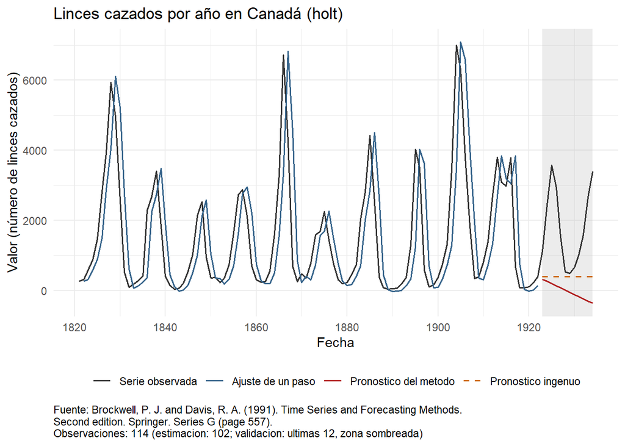

```r
g_final <- grafico_pronostico(datos, n_est, ajuste$yhat, pron, "Linces cazados por año en Canadá (holt)", ingenuo = pron_ing)
ggsave("figs/contra-final.png", g_final, width = 8, height = 4.5)
g_final
```

En la representación gráfica de las proyecciones se evidencia la limitación estructural del modelo. El método de Holt Lineal está diseñado exclusivamente para capturar y proyectar series con tendencia, pero carece de los mecanismos necesarios para modelar series con componentes estacionales. En consecuencia, la trayectoria pronosticada no logra seguir los giros ni la periodicidad característica de los datos reales, sobreestimando o subestimando.

Al final del periodo de entrenamiento (justo antes de la zona sombreada), la serie venía cayendo. Por eso, el modelo de Holt asume de forma rígida que esa caída continuará y proyecta una pendiente negativa hacia abajo (línea roja), perdiendo totalmente la curva de recuperación que hace la serie real. En cambio, el pronóstico ingenuo (línea punteada), aunque simplista, se mantiene plano cerca del valle y termina cometiendo un error mucho menor que la línea descendente de Holt.